# HBOI, Edge lab, González Angel thesis, Porites astreoides larvae salinity challenge

Lisa Cohen

# Porites astreoites microarray

Script used to generate this document:

https://github.com/ljcohen/Porites_astreoites_larvae_salinity/blob/master/microarray/Past_salinity_2016-07-01_featureAVG_probeset_analysis.Rmd

QC report:

https://ljcohen.github.io/Porites_astreoites_larvae_salinity/microarray/QC/salinity_ArrayQualityMetrics_log_collapsed_by_transcriptName_quantilenorm_filtered/index.html

Import R/Bioconductor libraries, set path to directory where raw data files are located, and overLapper venn diagram script:

F532 Median - B532 data were manually extracted from GenePix .txt files, all samples compiled together manually into .csv. (In the future, data extraction can be automated. We no longer have the original .txt files.) Dimensions should be 15744 x 16:

```
## [1] 15744    16
```

Get rid of data that were flagged “BAD” = -100. Dimensions should be 15732 x 16:

```
## [1] 15732    16
```

Import and merge annotations file.

```
## [1] 15732    23
```

```
##  [1] "spot"                           "Flags"
##  [3] "Column"                         "Row"
##  [5] "Name"                           "ID"
##  [7] "RefNumber"                      "c253295110048_ar2_jun1912_A_SL"
##  [9] "c253295110048_ar1_jun1912_B_SL" "c253295110048_ar4_jun1912_C_SL"
## [11] "c253295110048_ar3_jun1912_A_L"  "c253295110048_ar6_jun1912_B_L"
## [13] "c253295110048_ar5_jun1912_C_L"  "c253295110048_ar8_jun1912_A_C"
## [15] "c253295110048_ar7_jun1912_B_C"  "c253295110054_ar2_jul1112_C_C"
```

Remove controls, display number of annotations that are not controls. Should be 12,354:

```
## [1] 12354    23
```

Displays number of unique gene names, should be 2206:

```
## [1] 2206
```

```
## [1] 4118   10
```

```
## [1] 2206   10
```

Analyze data collapsed by name = salinity.probeset.name. This is “probeset” = same trancript/gene. Mean of intensities for all matching third position:

```
##                            Name c253295110048_ar2_jun1912_A_SL
## 1  109895125_DQ647776.1_101-739                      0.5555556
## 2  117650137_EF036564.1_239-937                   1332.3333333
## 3  117937764_EF036594.1_58-1338                    299.5000000
## 4 119654707_EF036595.2_367-1338                   1177.3333333
## 5  122086255_AB289569.1_400-594                      0.0000000
## 6  124507305_EF363320.1_351-617                      2.3333333
##   c253295110048_ar1_jun1912_B_SL c253295110048_ar4_jun1912_C_SL
## 1                      1.2222222                     -0.1111111
## 2                   1998.3333333                    639.6666667
## 3                    441.3333333                    167.0000000
## 4                   1738.6666667                    628.2222222
## 5                      1.0000000                     -0.3333333
## 6                     -0.8333333                      1.3333333
##   c253295110048_ar3_jun1912_A_L c253295110048_ar6_jun1912_B_L
```

[output cut: 20 more lines]

```
## [1] 2206   10
```

Set all negative values to 0, transform all data + 1, # log base2 transform all data:

Normalize between arrays:

The dimensions of the filtered data frame after normalization:

```
## [1] 379   8
```

PCA

```
## [1] "c253295110048_ar2_jun1912_A_SL" "c253295110048_ar1_jun1912_B_SL"
## [3] "c253295110048_ar4_jun1912_C_SL" "c253295110048_ar3_jun1912_A_L"
## [5] "c253295110048_ar6_jun1912_B_L"  "c253295110048_ar5_jun1912_C_L"
## [7] "c253295110048_ar8_jun1912_A_C"  "c253295110048_ar7_jun1912_B_C"
```

```
## [1] "sal25ppt_A" "sal25ppt_B" "sal25ppt_C" "sal30ppt_A" "sal30ppt_B"
## [6] "sal30ppt_C" "sal35ppt_A" "sal35ppt_B"
```

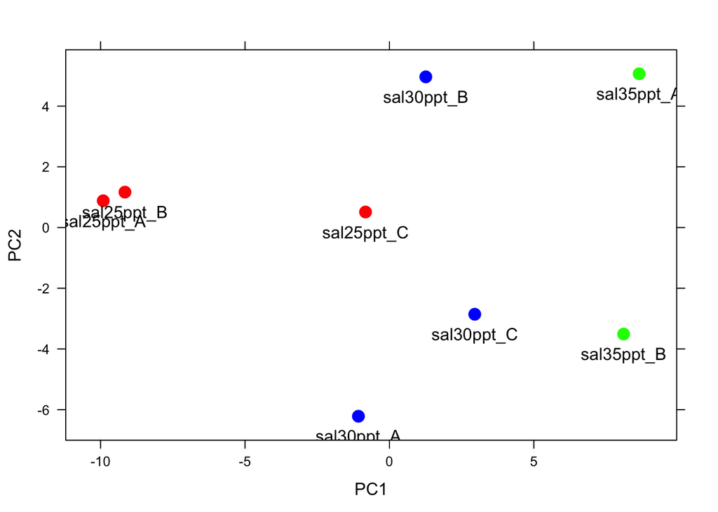

```
##   sal35ppt sal30ppt sal25ppt
## 1        1        0        0
## 2        1        0        0
## 3        1        0        0
## 4        0        1        0
## 5        0        1        0
## 6        0        1        0
## 7        0        0        1
## 8        0        0        1
## attr(,"assign")
## [1] 1 1 1
## attr(,"contrasts")
## attr(,"contrasts")$`factor(c(1, 1, 1, 2, 2, 2, 3, 3))`
## [1] "contr.treatment"
```

```
## An object of class "MArrayLM"
## $coefficients
##                                Contrasts
##                                 sal25ppt - sal30ppt sal25ppt - sal35ppt
##   117650137_EF036564.1_239-937           0.08154801         -0.17098336
##   117937764_EF036594.1_58-1338          -0.20641175         -0.25754195
##   119654707_EF036595.2_367-1338          0.15984686         -0.01404522
##   124507305_EF363320.1_351-617          -0.23192220         -0.03137282
##   124507317_EF363324.1_205-516           0.96318950         -0.12402407
##                                Contrasts
##                                 sal30ppt - sal35ppt
##   117650137_EF036564.1_239-937           -0.2525314
##   117937764_EF036594.1_58-1338           -0.0511302
##   119654707_EF036595.2_367-1338          -0.1738921
##   124507305_EF363320.1_351-617            0.2005494
##   124507317_EF363324.1_205-516           -1.0872136
## 374 more rows ...
##
## $rank
## [1] 3
##
## $assign
## [1] 1 1 1
##
## $qr
## $qr
##     sal35ppt   sal30ppt   sal25ppt
## 1 -1.7320508  0.0000000  0.0000000
## 2  0.5773503 -1.7320508  0.0000000
## 3  0.5773503  0.0000000 -1.4142136
## 4  0.0000000  0.5773503  0.0000000
## 5  0.0000000  0.5773503  0.0000000
## 6  0.0000000  0.5773503  0.0000000
## 7  0.0000000  0.0000000  0.7071068
## 8  0.0000000  0.0000000  0.7071068
## attr(,"assign")
## [1] 1 1 1
## attr(,"contrasts")
## attr(,"contrasts")$`factor(c(1, 1, 1, 2, 2, 2, 3, 3))`
## [1] "contr.treatment"
```

[output cut: 236 more lines]

```
##                                 sal30ppt - sal35ppt
##   117650137_EF036564.1_239-937            -4.237857
##   117937764_EF036594.1_58-1338            -5.899114
##   119654707_EF036595.2_367-1338           -4.939270
##   124507305_EF363320.1_351-617            -6.021757
##   124507317_EF363324.1_205-516            -3.780487
## 374 more rows ...
##
## $F
## [1] 2.32144372 3.59394163 1.45653750 0.07248814 3.49716952
## 374 more elements ...
##
## $F.p.value
## [1] 0.17444091 0.08978814 0.30098640 0.93082823 0.09400967
## 374 more elements ...
```

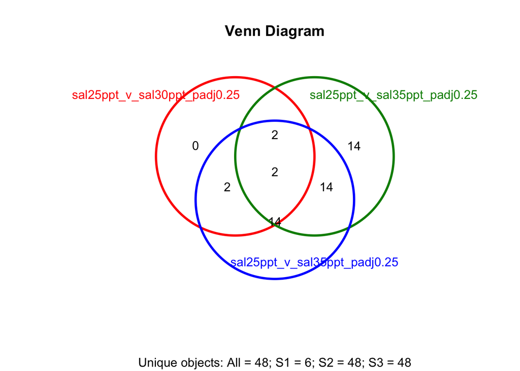

Make heatmap of 25ppt vs. 35 ppt, log2FC > 1 and log2FC < -1

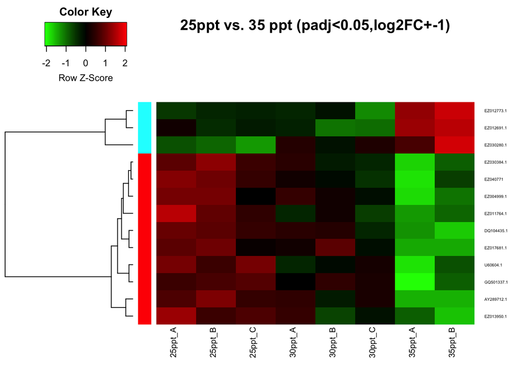

References:

Ritchie, ME, Phipson, B, Wu, D, Hu, Y, Law, CW, Shi, W, and Smyth, GK (2015). limma powers differential expression analyses for RNA-sequencing and microarray studies. Nucleic Acids Research 43(7), e47.

Smyth, G. K. (2004). Linear models and empirical Bayes methods for assessing differential expression in microarray experiments. Statistical Applications in Genetics and Molecular Biology, Vol. 3, No. 1, Article 3. http://www.statsci.org/smyth/pubs/ebayes.pdf

limma Manual: https://www.bioconductor.org/packages/devel/bioc/vignettes/limma/inst/doc/usersguide.pdf

limma Bioconductor: https://bioconductor.org/packages/release/bioc/html/limma.html